# Fuel Efficiency

Andrew Mahurin

06/13/2015

## Question

How has fuel efficency improved over the last 5 or 10 years?

```r
df = read.csv("~/program/UMTRI_sales-weighted-MPG_May-2015.csv")
head(df)
```

```
##   Month.Year Sales.weighted_MPG
## 1 2007/10/01               20.1
## 2 2007/11/01               20.4
## 3 2007/12/01               20.1
## 4 2008/01/01               20.5
## 5 2008/02/01               20.4
## 6 2008/03/01               20.8
```

```r
summary(df)
```

```
##       Month.Year Sales.weighted_MPG
##  2007/10/01: 1   Min.   :20.1
##  2007/11/01: 1   1st Qu.:22.0
##  2007/12/01: 1   Median :22.7
##  2008/01/01: 1   Mean   :23.1
##  2008/02/01: 1   3rd Qu.:24.8
##  2008/03/01: 1   Max.   :25.8
##  (Other)   :86
```

## Converting the data to gallons per 100 miles

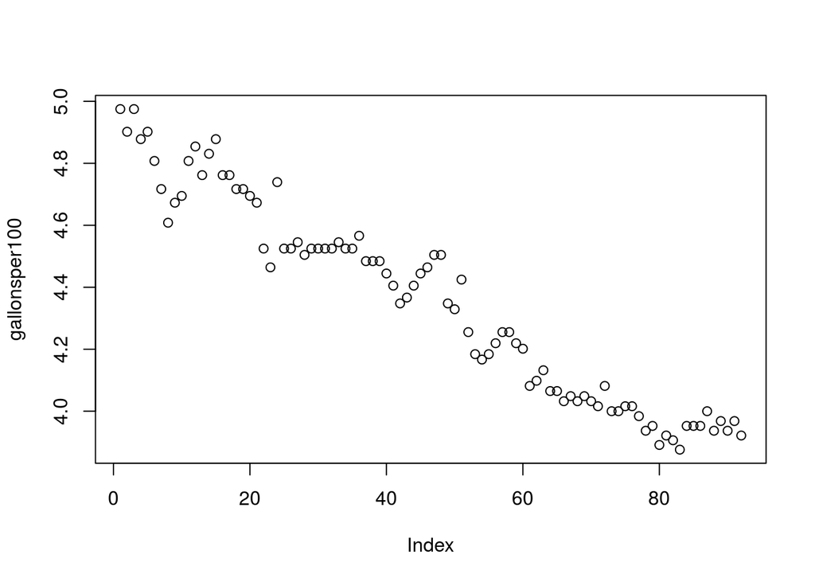

```r
gallonsper100 = 100 /df$Sales.weighted_MPG
plot(gallonsper100)
```

## Calculating a regression

```r
n = length(gallonsper100)
print(n)
```

```
## [1] 92
```

```r
index = 1:n
res = lm(gallonsper100 ~ index)
#           df$Month.Year)
summary(res)
```

```
##
## Call:
## lm(formula = gallonsper100 ~ index)
##
## Residuals:
##      Min       1Q   Median       3Q      Max
## -0.19878 -0.05328  0.00549  0.04060  0.16454
##
## Coefficients:
##              Estimate Std. Error t value Pr(>|t|)
## (Intercept)  4.900500   0.015696   312.2   <2e-16 ***
## index       -0.011678   0.000293   -39.8   <2e-16 ***
## ---
## Signif. codes:  0 '***' 0.001 '**' 0.01 '*' 0.05 '.' 0.1 ' ' 1
##
## Residual standard error: 0.0747 on 90 degrees of freedom
## Multiple R-squared:  0.946,  Adjusted R-squared:  0.946
## F-statistic: 1.59e+03 on 1 and 90 DF,  p-value: <2e-16
```

## Plotting the results

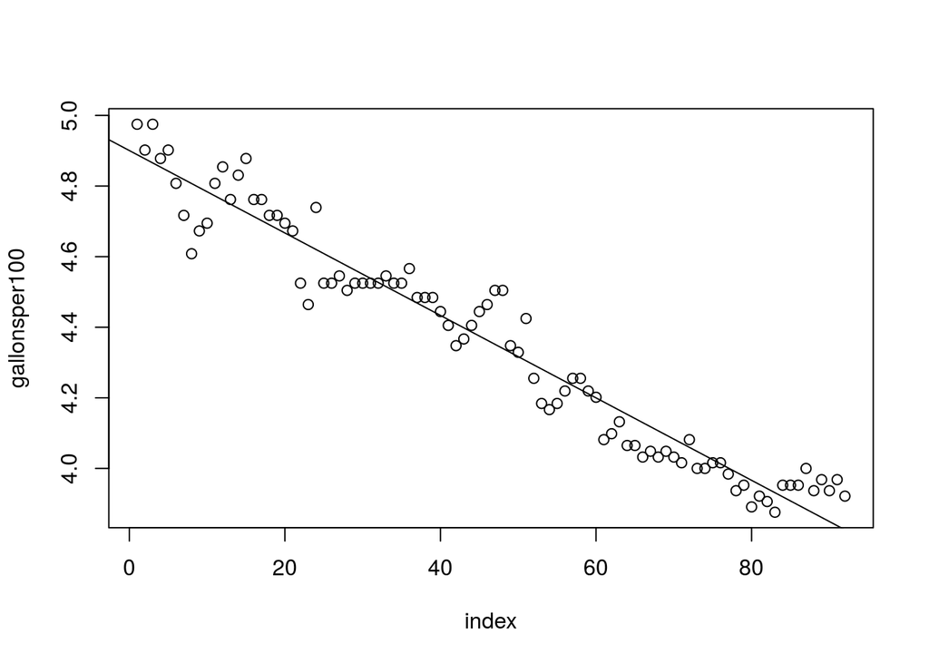

```r
plot(gallonsper100 ~ index)
abline(res)
```

## Converting the data to logarhythmic values

```r
res2 = lm(log(gallonsper100)~index)
summary(res2)
```

```
##
## Call:
## lm(formula = log(gallonsper100) ~ index)
##
## Residuals:
##      Min       1Q   Median       3Q      Max
## -0.04452 -0.01227  0.00158  0.00959  0.03987
##
## Coefficients:
##              Estimate Std. Error t value Pr(>|t|)
## (Intercept)  1.59e+00   3.51e-03   454.4   <2e-16 ***
## index       -2.68e-03   6.55e-05   -40.9   <2e-16 ***
## ---
## Signif. codes:  0 '***' 0.001 '**' 0.01 '*' 0.05 '.' 0.1 ' ' 1
##
## Residual standard error: 0.0167 on 90 degrees of freedom
## Multiple R-squared:  0.949,  Adjusted R-squared:  0.948
## F-statistic: 1.67e+03 on 1 and 90 DF,  p-value: <2e-16
```

## Plotting the data with the regression

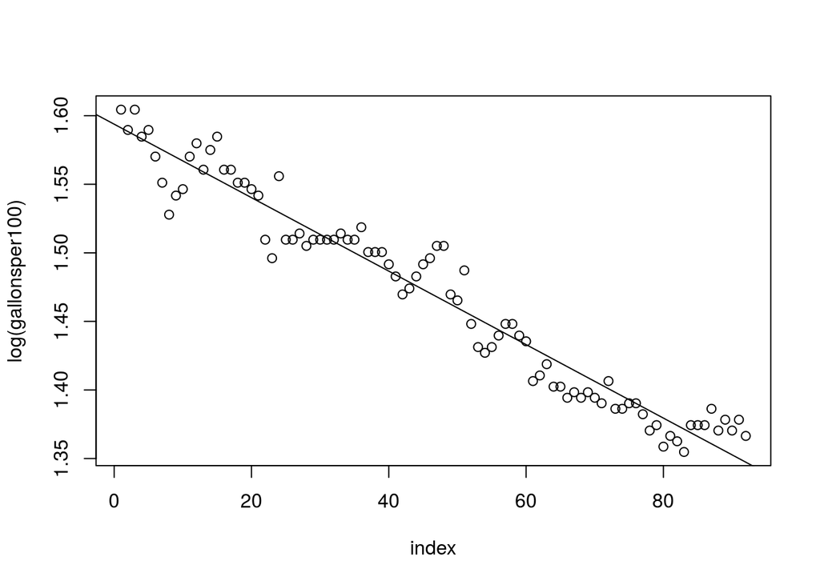

```r
plot(log(gallonsper100)~ index)
abline(res2)
```

## Regressing on differences of logs

```r
index = 1:length(diff(log(gallonsper100)))
res3 = lm(diff(log(gallonsper100))~index)
summary(res3)
```

```
##
## Call:
## lm(formula = diff(log(gallonsper100)) ~ index)
##
## Residuals:
##      Min       1Q   Median       3Q      Max
## -0.04317 -0.00624  0.00219  0.00790  0.06295
##
## Coefficients:
##              Estimate Std. Error t value Pr(>|t|)
## (Intercept) -3.71e-03   3.12e-03   -1.19     0.24
## index        2.38e-05   5.89e-05    0.40     0.69
##
## Residual standard error: 0.0148 on 89 degrees of freedom
## Multiple R-squared:  0.00183,    Adjusted R-squared:  -0.00939
## F-statistic: 0.163 on 1 and 89 DF,  p-value: 0.687
```

This shows that there is no significant slowdown in the tendancy for cars to get more fuel efficient over time. There is some slowdown, but it is not statistically significant. This concludes the study of how fuel efficiency changes over time. There is a clear trend in the fuel efficiency of automobiles the last several years. The trend appears to be stable, and not slowing down much in the last few years. A regression on the first differences does not reveal a secondary trend in the data. Having a series which is stable relative to any time trend allows for other variables to be measured to see whether they had any effect on the fuel efficiency of vehicles. The next step would be to see whether there is any correlation between fuel efficiency and any other variable. The first question would be to see whether there is any correlation between the price of gasoline and the month-to-month improvements in fuel efficiency.

## Plotting first differences of logs

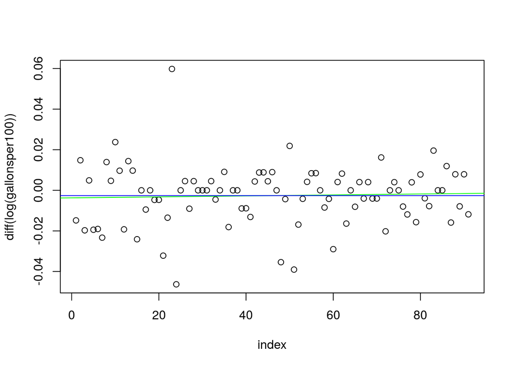

```r
index = 1:length(diff(log(gallonsper100)))
plot(diff(log(gallonsper100))~ index)
abline(res3, col = "green")
abline(h = mean(diff(log(gallonsper100))), col = "blue")
```

This shows that the trend for greater fuel efficiency in cars is stable accross time. The line for the mean improvement in fuel efficiency is almost equivalent to the line for the regression on the first differences.

## Finding the annual change in fuel efficiency

```r
annual = res2$coefficients[2] *12
print(annual)
```

```
##    index
## -0.03215
```

```r
print(exp(annual))
```

```
##  index
## 0.9684
```

A difference in logs of -.03 equates to a percentage change of about -3%. At this point it would be nice to open the data that has to do with the price of gasoline. There are several sources of data for the price of gasoline for the last several years. None of them have been selected yet.

## Selecting a source of data for historic fuel prices

The EIA, the AAA, and the World Bank all have historic data on the price of gas. The Energy Information Administration seems to have the most high quality data, but they actually have multiple types of gas that they have data for. The data that they have is also the most difficult to load in, because of its missing data values.